# CS401Lab2a

```python
!jupyter nbconvert --to html /content/CS401Lab2a.ipynb
```

[output not shown]

(1) Data Exploration and Preparation (15 points): (a) Load the Iris dataset and examine its structure. (b) Explore the dataset by calculating summary statistics and visualizing the data using appropriate plots (e.g., histograms, scatter plots). (c) Split the dataset into training (80%) and testing sets (20%).

```python
#a) Load the Iris dataset and examine its structure.
import pandas as pd
from sklearn import datasets

iris = datasets.load_iris()
irisDS = iris.data
df = pd.DataFrame(data=irisDS, columns=iris.feature_names)
print(df)
print(df.mean())
print(df.min())
print(df.max())
```

```
     sepal length (cm)  sepal width (cm)  petal length (cm)  petal width (cm)
0                  5.1               3.5                1.4               0.2
1                  4.9               3.0                1.4               0.2
2                  4.7               3.2                1.3               0.2
3                  4.6               3.1                1.5               0.2
4                  5.0               3.6                1.4               0.2
..                 ...               ...                ...               ...
145                6.7               3.0                5.2               2.3
146                6.3               2.5                5.0               1.9
147                6.5               3.0                5.2               2.0
148                6.2               3.4                5.4               2.3
149                5.9               3.0                5.1               1.8

[150 rows x 4 columns]
sepal length (cm)    5.843333
sepal width (cm)     3.057333
petal length (cm)    3.758000
petal width (cm)     1.199333
dtype: float64
sepal length (cm)    4.3
sepal width (cm)     2.0
petal length (cm)    1.0
petal width (cm)     0.1
dtype: float64
sepal length (cm)    7.9
sepal width (cm)     4.4
petal length (cm)    6.9
petal width (cm)     2.5
dtype: float64
```

(a) Here we can see there is 150 rows, 4 columns.

The 4 columns consist of sepal length, sepal width, petal length & petal width.

Listed, are the Mean, Minimum and Maximum values of each.

Overall, the expected results are seen here. The average lengths are bigger than the widths.

```
       sepal length (cm)  sepal width (cm)  petal length (cm)  \
count         150.000000        150.000000         150.000000
mean            5.843333          3.057333           3.758000
std             0.828066          0.435866           1.765298
min             4.300000          2.000000           1.000000
25%             5.100000          2.800000           1.600000
50%             5.800000          3.000000           4.350000
75%             6.400000          3.300000           5.100000
max             7.900000          4.400000           6.900000

       petal width (cm)
count        150.000000
mean           1.199333
std            0.762238
min            0.100000
25%            0.300000
50%            1.300000
75%            1.800000
max            2.500000
```

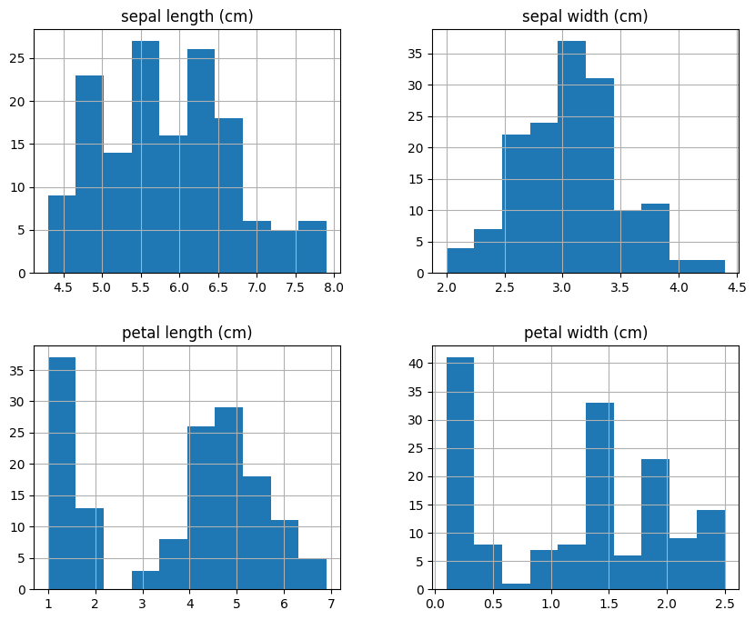

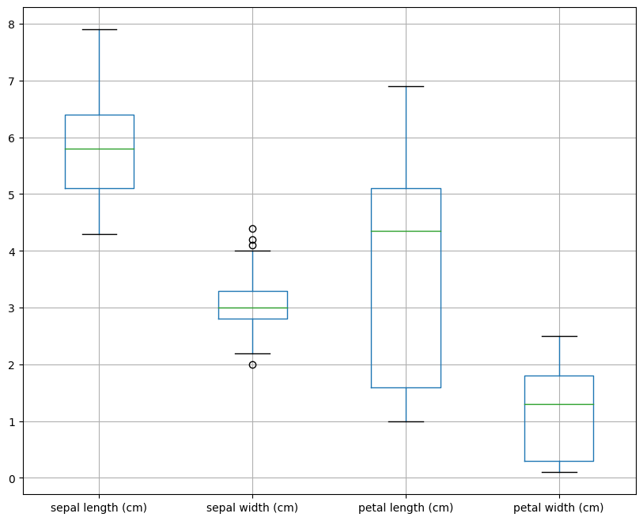

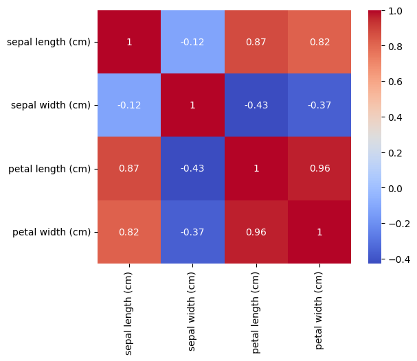

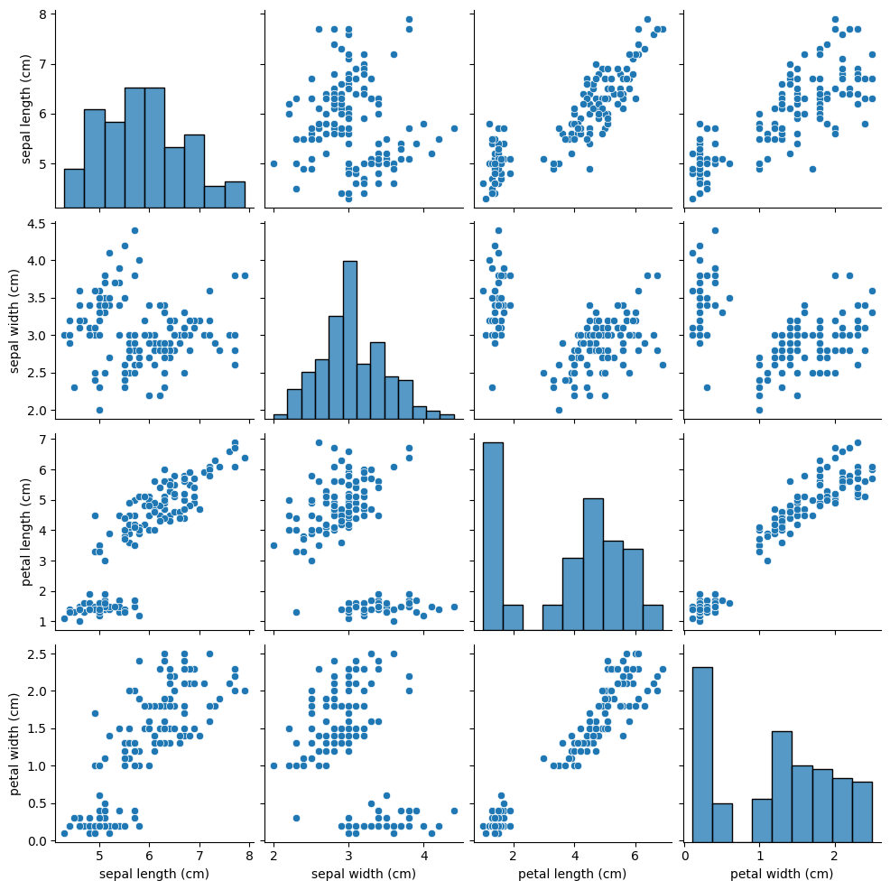

```python
#(b) Explore the dataset by calculating summary statistics and visualizing the data using appropriate plots (E.G Histograms, Scatter Plots)
import matplotlib.pyplot as plt
import seaborn as sns

summary_statistics = df.describe()
print(summary_statistics)

df.hist(figsize=(10, 8))
plt.show()
df.boxplot(figsize=(10, 8))
plt.show()
sns.heatmap(df.corr(), annot=True, cmap='coolwarm', square=True)
plt.show()
sns.pairplot(df)
plt.show()
```

(b) Here is a combination of boxplots, histograms, heat maps, pair plots and summary statistics as well.

In the HeatMap, we can see the that theres a very high correlation with all of these excet for sepal width. If you look at the boxplots, you can see that the sepal width is the only one with visible outliers.

With the summary statistics, we can again see there is 150 total here, and it also has the mean, std, min, max & quartiles.

```python
#(c) Split the dataset into training (80%) and testing sets (20%).
from sklearn.linear_model import LinearRegression
from sklearn.model_selection import train_test_split

# Split
x_train, x_test, y_train, y_test = train_test_split(irisDS, iris.target, test_size=0.2)
#Test_size = 0.2 = 20% Data set

#Resulting sets
print("shape of original dataset: ", irisDS.shape)
print("shape of input - training set", x_train.shape)
print("shape of output - training set", y_train.shape)
print("shape of input - testing set", x_test.shape)
print("shape of output - testing set", y_test.shape)
```

```
shape of original dataset:  (150, 4)
shape of input - training set (120, 4)
shape of output - training set (120,)
shape of input - testing set (30, 4)
shape of output - testing set (30,)
```

(c)

There's 150 rows in this dataset. 1.5 = 1%, 15 = 10%, 30 = 20%.

This was split up into 80%/20% splits. That's why the train.shape's are 120 & the test.shape's are 30.

It's common pracctice for the split to be 80/20, and that is done by doing test_size = 0.2 when Splitting the Dataset.

Decision Tree Implementation (30 points): (a) Implement a decision tree classifier using scikit-learn's DecisionTreeClassifier class. (b) Train the decision tree classifier on the training data. (c) Set and tune hyperparameters like the maximum depth of the tree, minimum samples per leaf, or other relevant parameters.

```python
#(a) Implement a decision tree classifier using scikit-learn's DecisionTreeClassifier class.
#(b) Train the decision tree classifier on the training data.
from sklearn.tree import DecisionTreeClassifier
from sklearn.metrics import accuracy_score, classification_report

#Decision Tree
classifier = DecisionTreeClassifier(random_state=2)
classifier.fit(x_train, y_train)

Accuracy = accuracy_score(y_test, classifier.predict(x_test))
print("Accuracy:", Accuracy)
print(classification_report(y_test, classifier.predict(x_test)))
```

```
Accuracy: 0.9666666666666667
              precision    recall  f1-score   support

           0       1.00      1.00      1.00        11
           1       1.00      0.91      0.95        11
           2       0.89      1.00      0.94         8

    accuracy                           0.97        30
   macro avg       0.96      0.97      0.96        30
weighted avg       0.97      0.97      0.97        30
```

This isn't loading in the HTML file for some reason.

Here is the result as I see it:

Accuracy: 0.9666666666666667

[output not shown]

macro avg 0.96 0.97 0.96 30 weighted avg 0.97 0.97 0.97 30

(a) First of all, we import the necessary models. Then we create the Decision Tree Classifier & start to train it. This is done using classifier.fit(). we can use .prediction to make predictions on the testing set. Following this, the model is evaluated. It's calculated by using the accuracy_score function. Following that, all we have to do is show a report on this.

(b) This code creates a decision tree classifier. The state is random using 'random_state=2' for reproducability. And then it trains the classifier using training data.

The 'random_state' parameter in the 'DecisionTreeClassifier' constructor is used for RNG. Because the random state is fixed at 2, it means it is reproducible.

```python
#(c) Set and tune hyperparameters like the maximum depth of the tree,
#minimum samples per leaf, or other relevant parameters.
from sklearn.model_selection import GridSearchCV

# Hyperparameters
param_grid = {
    'max_depth': [None, 1, 5, 10],  # Maximum depth of the decision tree. None = unrestricted depth.
    'min_samples_leaf': [1, 2, 5, 10]  # Minimum samples per leaf as 1 2, 5, or 10.
}
grid_search = GridSearchCV(classifier, param_grid, cv=5)
grid_search.fit(x_train, y_train)
print("Best Parameters:", grid_search.best_params_) #I swear these _'s annoy me

# Most suitable Hyperparameters
best_classifier = DecisionTreeClassifier(random_state=2,
    max_depth=grid_search.best_params_['max_depth'],
    min_samples_leaf=grid_search.best_params_['min_samples_leaf'])
best_classifier.fit(x_train, y_train)


# Evaluate the model with the best hyperparameters
accuracy_best = accuracy_score(y_test, best_classifier.predict(x_test))
print("Accuracy with best hyperparameters:", accuracy_best)
print(classification_report(y_test, best_classifier.predict(x_test)))
```

```
Best Parameters: {'max_depth': None, 'min_samples_leaf': 2}
Accuracy with best hyperparameters: 0.9333333333333333
              precision    recall  f1-score   support

           0       1.00      1.00      1.00        11
           1       0.91      0.91      0.91        11
           2       0.88      0.88      0.88         8

    accuracy                           0.93        30
   macro avg       0.93      0.93      0.93        30
weighted avg       0.93      0.93      0.93        30
```

(c) Set and tune hyperparameters like the maximum depth of the tree, minimum samples per leaf, or other relevant parameters.

The max depth controls the depth of the DT. The Maximum depth being none mean there is no restriction on how deep it should go. The min_samples_leaf controls the minimum number of samples required to be at the node. So we have them as either 1,2,5, or 10.

GridSearchCV searches through param_grid using **Cross-Validation** It then shows the best combinations found by the grid to get the highest performance.

We go on to get the most suitable hyperparamaeters, predict the testing set and show that the end result is.

1. Model Evaluation (20 points):

Use the trained classifier to predict the species of iris flowers in the testing dataset. Evaluate the model's performance using appropriate classification metrics such as accuracy, precision, recall, F1-score, etc.

```python
#(a) Use the trained classifier to predict the species of iris flowers in the testing dataset.

classifier.fit(x_train, y_train)
print("Predicted labels for the testing dataset:")
print(classifier.predict(x_test))
```

```
Predicted labels for the testing dataset:
[0 0 2 0 2 0 1 1 2 1 2 0 1 2 0 1 1 2 1 0 2 1 1 2 1 0 2 0 0 0]
```

classifier.predict predicts the species of iris flowers in the Iris Dataset.

```python
#(b) Evaluate the model's performance using appropriate classification metrics such as accuracy, precision, recall, F1-score, etc.
from sklearn.metrics import classification_report

y_check = classifier.predict(x_test)
# Evaluate the model's performance using classification metrics
classification_metrics = classification_report(y_test, y_check, target_names=iris.target_names)
print(classification_metrics)
```

```
              precision    recall  f1-score   support

      setosa       1.00      1.00      1.00        11
  versicolor       1.00      0.91      0.95        11
   virginica       0.89      1.00      0.94         8

    accuracy                           0.97        30
   macro avg       0.96      0.97      0.96        30
weighted avg       0.97      0.97      0.97        30
```

The code makes a classification report that shows the model testing the Iris dataset using the data it had gotten from the testing set. It prints the precision, recall, f1-score, support, setosa, versicolor, virginica, accuracy, macro avg & weighted avg.

1. Visualization (15 points): Visualize the decision tree structure that you've built, showing how it makes decisions based on the features.

[figure not shown]

```python
#(a)
from sklearn.tree import plot_tree

# Visualize the decision tree structure
plt.figure(figsize=(20, 10))
plot_tree(classifier, filled=True, feature_names=iris.feature_names, class_names=iris.target_names)
plt.title("Decision Tree Structure")
plt.show()
```

1. Discussion and Conclusion (20 points): Summarize the key findings from your analysis, including the model's performance and the structure of the decision tree.

Summarize the key findings from the analysis, including the model's performance and the structure of the decision tree.

Key Findings: Data Exploration and Preparation (15 points): Iris Data set has 150 rows, 4 columns, made up of sepal (width & length) and Petal (width & length)

We have made a decision tree classifier and we further trained it using the Iris dataset.

The trained decision tree classifier was used to predict the species of iris flowers in the testing dataset. Following that, the decision tree was visualized and color code into boxes.

The model is accurate to the testing dataset & indicates the ability to predict the what type of flower is being shown.

Decision Tree Structure: The decision tree structure was visualized, providing insights into how the model makes decisions based on the features. It helps understand the criteria at each node for predicting the target variable.